Functions

Lecture 3

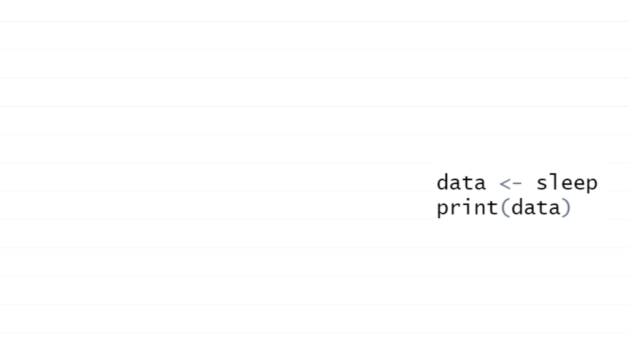

Review

- Sleep dataset

- Experimental group consumed drug → measured hours of

sleep difference

- Statistical inference in R

- Variables are placeholders

- variable_name <- variable_value

- PEMDAS applies to R math operations

- Vectors are values of the same type concatenated together

- c(element1, element2, element3, etc)

dataset_name$column_name

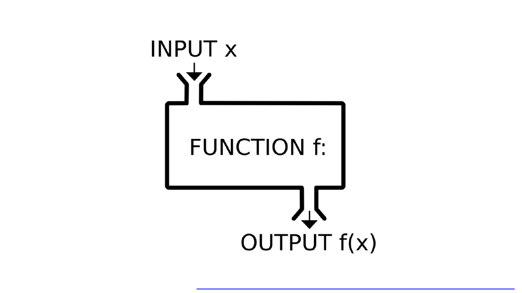

Image credit: https://blogs.oracle.com/developers/the-power-of-functional-programming

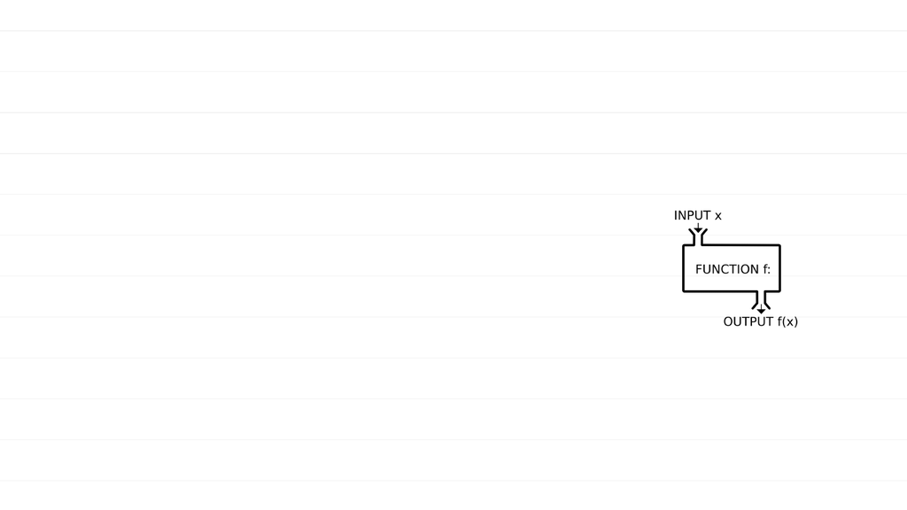

What are functions?

• Similar to functions f(x) in math:

– you can give it some x, and it will give you some f(x) back

• Like a magic box that does stuff for you

– “Don’t reinvent the wheel”

• You must call the function for it to work

• Pass the function a argument: the x value in f(x)

• Some functions return things to you: the resulting f(x) value

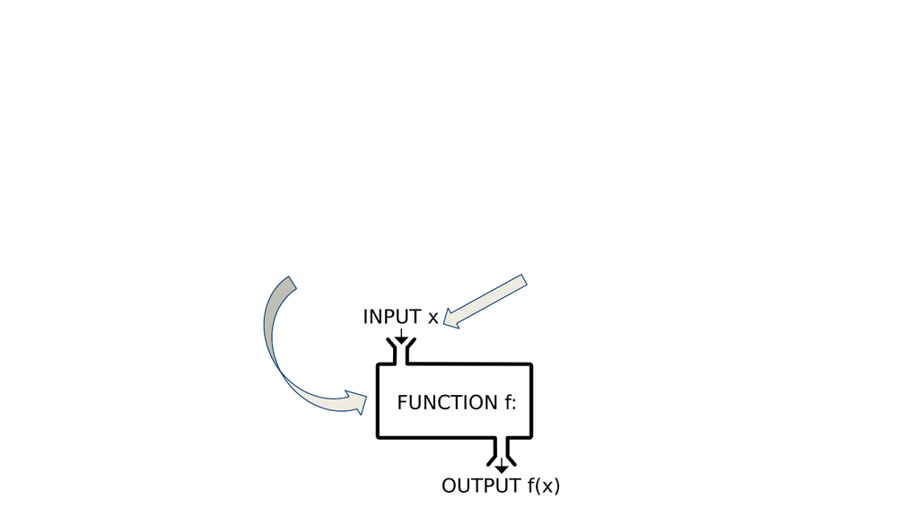

Function Call Syntax

functionName ( arguments )

You have collected data. Now,

you want to know the mean,

median, min, max of your data

[figure not shown]

Ex: function called mean()

Syntax

function_name(arguments)

• mean( c(1,2,3,4) )

• When run, returns 2.5

what I gave to the function, mean() takes a vector

what the function gives back to me

Your Turn: sleep dataset mean

- sleep$extra stores difference in hours

of sleep

- What is the mean difference in hours of

sleep students experienced?

Syntax Hint:

mean( c(1,2,3,4) )

> print(sleep)

extra group ID

1 0.7 1 1

2 -1.6 1 2

3 -0.2 1 3

4 -1.2 1 4

5 -0.1 1 5

6 3.4 1 6

7 3.7 1 7

8 0.8 1 8

9 0.0 1 9

10 2.0 1 10

11 1.9 2 1

12 0.8 2 2

13 1.1 2 3

14 0.1 2 4

15 -0.1 2 5

16 4.4 2 6

17 5.5 2 7

18 1.6 2 8

19 4.6 2 9

20 3.4 2 10

[figure not shown]

Ex: function called median()

Syntax

function_name(arguments)

• median( c(1,2,3,4) )

• When run, returns 2.5

what I gave to the function

what the function gives back to me

Your Turn: sleep dataset median

- What is the median difference in hours

of sleep students experienced?

Syntax Hint:

median( c(1,2,3,4) )

> print(sleep)

extra group ID

1 0.7 1 1

2 -1.6 1 2

3 -0.2 1 3

4 -1.2 1 4

5 -0.1 1 5

6 3.4 1 6

7 3.7 1 7

8 0.8 1 8

9 0.0 1 9

10 2.0 1 10

11 1.9 2 1

12 0.8 2 2

13 1.1 2 3

14 0.1 2 4

15 -0.1 2 5

16 4.4 2 6

17 5.5 2 7

18 1.6 2 8

19 4.6 2 9

20 3.4 2 10

[figure not shown]

Ex: functions called min() and max()

Syntax

function_name(arguments)

• min( c(1,2,3,4) )

• When run, returns 1

what I gave to the function

what the function gives back to me

Your Turn: sleep dataset min & max

- What are the minimum and maximum

difference in hours of sleep students

experienced?

Syntax Hint:

min( c(1,2,3,4) )

max( c(1,2,3,4) )

> print(sleep)

extra group ID

1 0.7 1 1

2 -1.6 1 2

3 -0.2 1 3

4 -1.2 1 4

5 -0.1 1 5

6 3.4 1 6

7 3.7 1 7

8 0.8 1 8

9 0.0 1 9

10 2.0 1 10

11 1.9 2 1

12 0.8 2 2

13 1.1 2 3

14 0.1 2 4

15 -0.1 2 5

16 4.4 2 6

17 5.5 2 7

18 1.6 2 8

19 4.6 2 9

20 3.4 2 10

Sleep dataset mean, median, min, max

mean(sleep$extra)

median(sleep$extra)

min(sleep$extra)

max(sleep$extra)

Ex: function called summary()

Syntax

function_name(arguments)

• Get all the previous information with just one function!

• summary( c(1,2,3,4) )

• When run, prints out:

Min. 1st Qu. Median Mean 3rd Qu. Max.

1.00 1.75 2.50 2.50 3.25 4.00

Review: Functions So Far

• mean(c(1,2,3,4))

• median(c(1,2,3,4))

• min(c(1,2,3,4))

• max(c(1,2,3,4))

• summary(c(1,2,3,4))

[figure not shown]

Terminology Review

• summary( c(1,2,3,4) )

• When run, prints out:

Min. 1st Qu. Median Mean 3rd Qu. Max.

1.00 1.75 2.50 2.50 3.25 4.00

what I gave to the function = argument

what the function gives back to me = return value/output

#Function call

[figure not shown]

Functions and Variables

• numbers <- c(1,2,3,4)

• mean <- mean(numbers)

• median <- median(numbers)

• min <- min(numbers)

• max <- max(numbers)

• summary <- summary(numbers)

• Can store function’s return value in a variable!

Your Turn: sleep dataset summary

- Store a summary of sleep hour

differences in a variable called

sleep_diff_summary

Syntax Hint:

summary( c(1,2,3,4) )

variable_name <- value

> print(sleep)

extra group ID

1 0.7 1 1

2 -1.6 1 2

3 -0.2 1 3

4 -1.2 1 4

5 -0.1 1 5

6 3.4 1 6

7 3.7 1 7

8 0.8 1 8

9 0.0 1 9

10 2.0 1 10

11 1.9 2 1

12 0.8 2 2

13 1.1 2 3

14 0.1 2 4

15 -0.1 2 5

16 4.4 2 6

17 5.5 2 7

18 1.6 2 8

19 4.6 2 9

20 3.4 2 10

Sleep dataset sleep_diff_summary

sleep_diff_summary <- summary(sleep$extra)

Why use Functions?

• Save time!

○ Does stuff for you

• Organize code/clarity

○ mean( c(1,2,3,4) ) VS (1 + 2 + 3 + 4) / 4

• First option makes it more clear you are

calculating mean

There are probably

hundreds of thousands of R

functions, if not more

No!

[figure not shown]

R Documentation

• https://www.rdocumentation.org/

○ Explains what each function does

○ What arguments it takes

○ Sometimes also provides an example

[figure not shown]

R Documentation: mean()

More Resources

• help() and ? will also bring up documentation

• help(mean)

• ?mean

• Google is our friend!

[figure not shown]

Other Functions

• nrow(_matrix here_)

○ Number of rows in a matrix

• ncol(_matrix here_)

○ Number of columns in a matrix

[figure not shown]

Your Turn: sleep dataset summary

- sleep can be considered a matrix

- How many rows (students) are in the sleep dataset? Store

this value in variable num_students

- How many columns are there? Store this in variable

num_variables

Syntax Hint:

nrow(_matrix here_)

ncol(_matrix here_)

Sleep nrow, ncol

• num_students <- nrow(sleep)

• num_variables <- ncol(sleep)

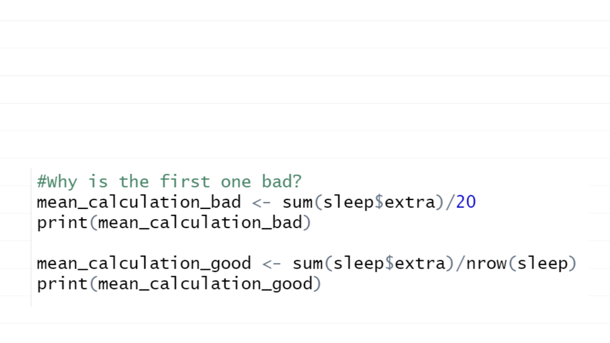

Hard-coding is BAD

• There are 20 students in the dataset, so both give

the correct mean value

Strive to make your code work even if data

changes (collect more data, exclude

samples)

Programmers are lazy! We want to reuse as

much code as possible

[figure not shown]

Other functions

• print()

○ You’ve seen this before!

○ Prints argument to console

○ Stops at ~250 rows of information

• View() view all data in a new tab

• sum() sums up values in vector

• sqrt(), exp(), log(), abs()

• sin() , cos() , tan() trigonometry

• More will be covered over this semester

Logistics

• Reminder: assignment 1 due next week

• Good faith attempt required

• Collaboration with other students encouraged